# Pacific Giant Salamanders in Mack Creek

Janelle Christensen & Lauren Manzo

12/04/2019

### Introduction

The pacific giant salamanders (*dicamptodon tenebrosus*) are a native species and the largest amphibians known in Oregon. Observing these species can give a clear signal on whether their water habitat is healthy as they are sensitive to water quality and are the first animals to react to negative impacts on their aquatic environment.

Since 1987 to present day, the Andrews Forest Long Term Ecological Research (Andrews Forest LTER) has been observing pacific giant salamanders as part of an aquatic vertebrate population study. The overall purpose of the study has been to observe the impacts of land use on the aquatic vertebrates. The research team conducted their work in Mack Creek located in the Andrews Experimental Forest in Oregon. The research team has been focusing on two specific areas of the creek: an upstream 500 year old coniferous forest and a clearcut forest.

Andrews Forest Long Term Ecological Reasearch has been using 2-pass electrofishing to capture specimen from the two regions of Mack Creek and measure and weigh each one for their records.

Figure 1. Andrews Forest Long Term Ecological Research Area

[figure not shown]

Credit: [EDI Data Portal](https://portal.edirepository.org/nis/mapbrowse?scope=knb-lter-and&identifier=4027&revision=12)

Figure 2. Pacific Giant Salamander

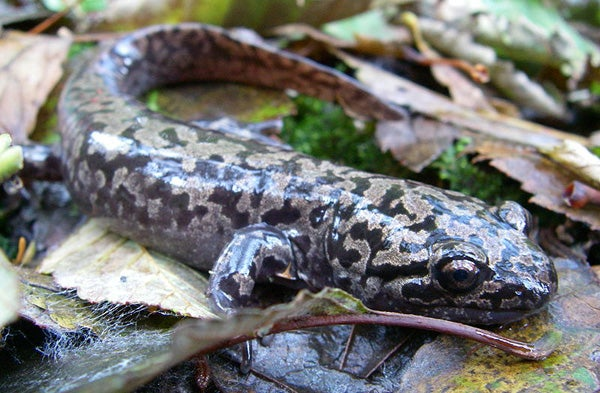

Credit: [Jeffrey Marsten Wikimedia](https://commons.wikimedia.org/wiki/File:Dicamptodon_tenebrosus_2.JPG)

### Data and Methods

Data for this project was collected from 1987 to present day by the Andrews Forest Long Term Ecological Research team. Salamander counts, measurements, and weights were annually collected at two 150 meter sections (clear cut and old growth) of Mack Creek. The two 150 meter sections were partinioned off in three 50 meter reaches by nets. Each 50 meter reach was then sampled with 2-pass electrofishing. Salamander trends in clear cut areas of Mack Creek were compared with salamander trends in old growth areas of Mack Creek. All data was analyzed and put into figures through the software R version 3.6.1.

### Results

##### 1. Observed annual salamander counts in old growth and clear cut sections of Mack Creek

In the two creek areas, annual salamander counts followed a similar trend. In 2017, there were 40 more salamanders in the clear cut area than in the old growth one.

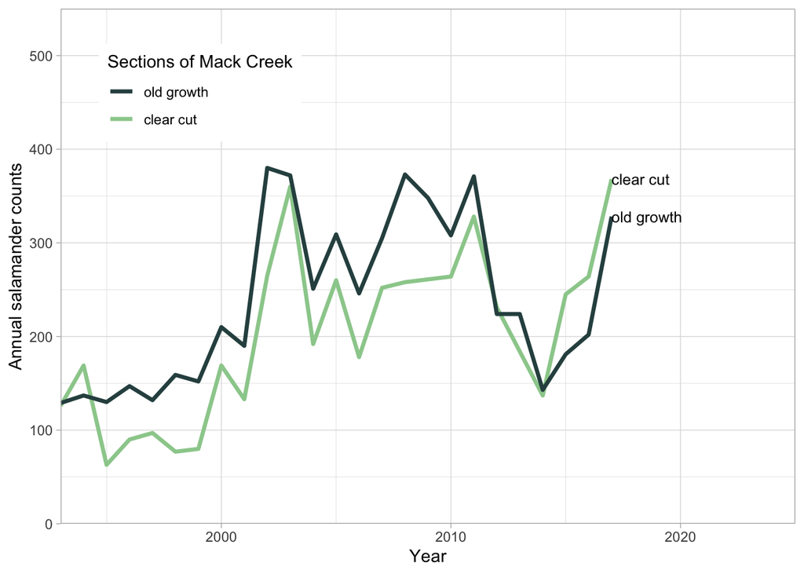

Figure 3: Annual salamander counts observed from 1993 - 2017 in two sections of Mack Creek that were either old growth (dark green) or clear cut (light green) in the Andrews Experimental Forest. Data: Andrews Forest LTER

##### 2. Table of 2017 salamander counts by channel classification (pool, cascades and side-channel) in old growth and clear cut sections of Mack Creek.

Figure 4. Numbers of salamanders observed in cascades, pools and side-channels in clear cut and old growth forest sections along Mack Creek. Percentages are relative to the area of the creek.

| Salamanders Observed in Mack Creek Area of Creek | Salamanders Observed in Mack Creek Clear Cut | Salamanders Observed in Mack Creek Old Growth |
| --- | --- | --- |
| Cascade | 247 (55.1%) | 201 (44.9%) |
| Pool | 31 (40.8%) | 45 (59.2%) |
| Side-Channel | 90 (54.9%) | 74 (45.1%) |

Based on these results, there is no observed association between where salamanders are found depending on whether or not they are in a clear cut or old growth section of Mack Creek ($\chi^2$ (2) = 5.54, p = 0.06) with a 95% confidence interval.

##### 3. Compared weights of Pacific giant salamanders in clear cut and old growth forest sections of Mack creek in 2017.

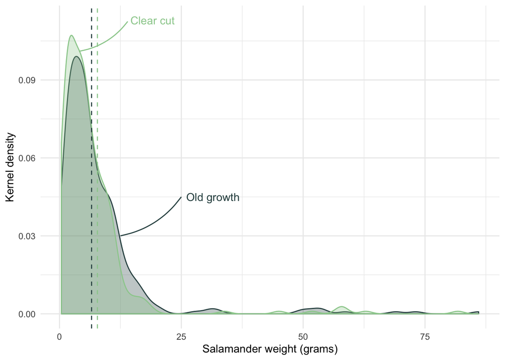

Figure 5: Salamander weight in old growth and clear cut areas in Mack Creek in 2017 and kernal density for mean salamandar weight in old growth areas (dark green) and in clear cut areas (light green) in 2017. The means are shown as dashed lines. Data: Andrews Forest LTER

For salamanders observed in the two types of forest in Mack Creek (n = 696), for old growth sections the mean weight of salamanders is 6.58 $\pm$ 8.96 and for clear cut sections the mean weight of salamanders is 7.78 $\pm$ 9.9 with an actual difference in mean size between the two setions being 1.19 (two-sided t-test, t (692.79) = 1.67, p = 0.1) with an effect size of 0.13. This indicates that there is no significant difference in weights of Salamanders observed between the two types of forest with a 95% confidence interval.

##### 4. Compared weights of Pacific giant salamanders in pools, cascades and side-channels of Mack Creek in 2017.

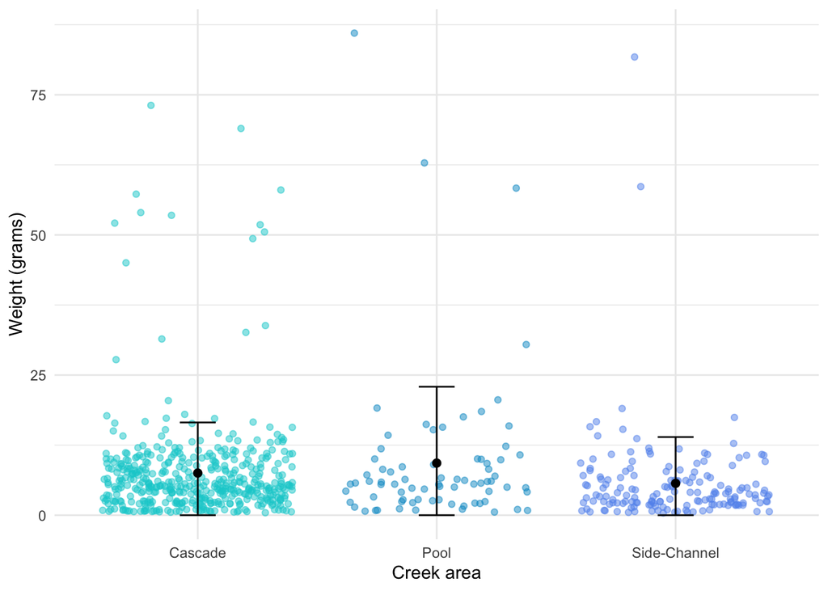

In Mack Creek in 2017 (n = 696), the mean weight for salamanders found in cascades was 7.52 $\pm$ 9.03, in pools the mean weight of salamanders was 9.3 $\pm$ 13.62, and for side-channels the mean weight of salamanders was 5.68 $\pm$ 8.27 (one-way ANOVA, F (684) = 4.22, p = 0.02). Using Tukey’s HSD, the post hoc pairwise testing shows that the mean weights of salamanders in pools differ significantly from salamanders in side-channels (p = 0.02). The significant difference in mean weight between salamanders is only seen between salamanders in pools and side-channels. Despite this, the effect size is relatively small (0.35). Between salamanders in pools and cascades, there is no observed significant difference in means (p = 0.29) with an effect size of 0.18. Similarly, there is no observed significant difference for salamanders in side-channels and in cascades: (p = 0.08) with an effect size of 0.21.

Despite the ANOVA being a strong test for statistical significance, comparing means of these samples may not be the most appropriate due to the positive skew and abonormal data distribution for all samples. For these samples, it might be best to compare medians, as medians are typically a stronger comparison for data that is positively skewed.

#### References

**Gregory S. V. 2016.** Aquatic Vertebrate Population Study in Mack Creek, Andrews Experimental Forest, 1987 to present. Environmental Data Initiative. https://doi.org/10.6073/pasta/5de64af9c11579266ef20da2ff32f702. Dataset accessed 11/19/2019.

**“Andrews Forest Data Web Site.”** Andrews Forest, andlter.forestry.oregonstate.edu/data/abstractdetail.aspx?dbcode=AS006.

**“Pacific Giant Salamander: Oregon Wild.”** Pacific Giant Salamander | Oregon Wild, oregonwild.org/wildlife/pacific-giant-salamander.